# Reordering Barplot Axes

Author

Robert W. Walker

The task is easiest accomplish by creating and plotting a table. In the event that we do not have the table, we will have to create counts. I will first show the table. The same technique with the addition of the count appears afterward.

# tidyTuesday Economist Data [`geom_col`]

I will rely on a small dataset of Facebook likes from the April 16, 2019 #tidyTuesday.[^1]

```r
corbyn <- readr::read_csv("https://raw.githubusercontent.com/rfordatascience/tidytuesday/master/data/2019/2019-04-16/corbyn.csv")
corbyn
```

| political_group | avg_facebook_likes |
| --- | --- |
| Jeremy Corbyn | 5210 |
| Labour Party | 845 |
| Momentum | 229 |
| Owen Smith | 127 |
| Andy Burnham | 105 |
| Saving Labour | 56 |

The data is perfect for our purposes because it is small but will also plot in an ugly order because of alphabetization. The first thing to emphasize is that the data need be in a tabular format; the raw data will not fit this approach. The goal of the short post is to demonstrate how to change the order of the $x$ or $y$ in a barplot.

## A Default Plot

I want to plot facebook likes and UK political figures. I will also flip the axes, change some labels, and remove the color legend because it is obvious from the plot.

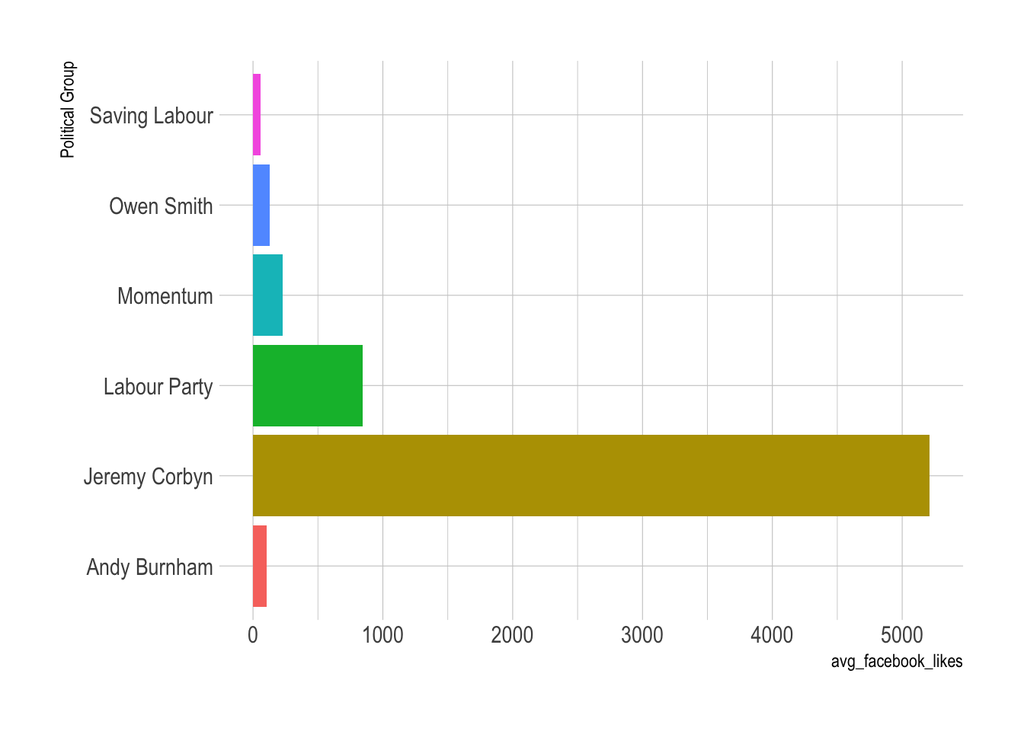

```r
corbyn %>%
  ggplot() +
  aes(x=political_group, avg_facebook_likes, y=avg_facebook_likes, fill=political_group) +
  geom_col() +
  coord_flip() +
  labs(x="Political Group") +
  guides(fill="none")
```

## Reordering political_group

The `forcats` package in the `tidyverse` contains a number of functions to assist with categorical variables. Here I will use `fct_reorder()` which will contain two options, what do I want to reorder and what variable determines the orders. I have provided a screen shot of the help file below.

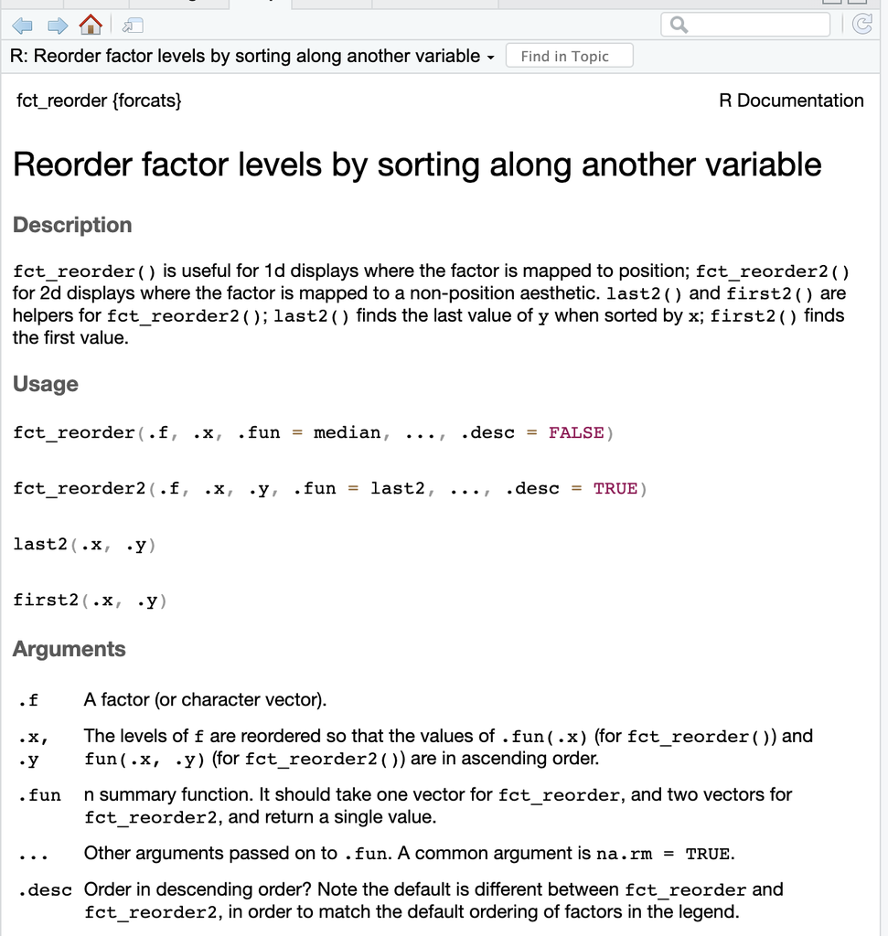

Help fct_reorder

My method for integrating this into the plot is to change the $x$ axis variable. Specifically, `fct_reorder(political_group, avg_facebook_likes)`. I order the political groups [the factor] by the number of average facebook likes [the x].

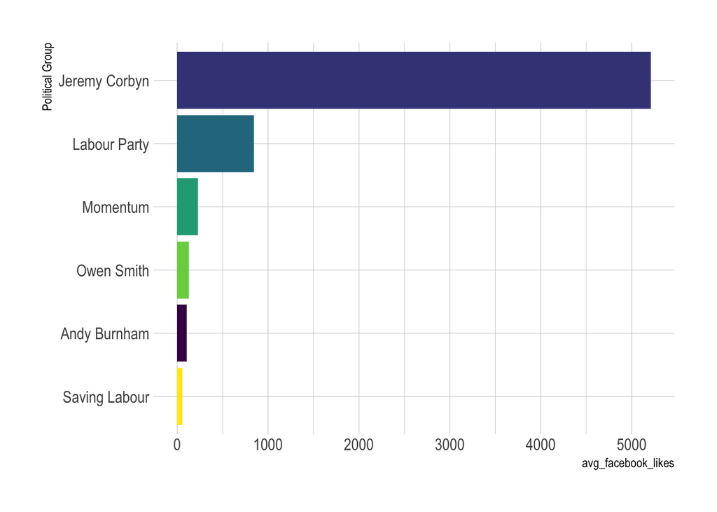

```r
corbyn %>%
  ggplot() +
  aes(x=fct_reorder(political_group, avg_facebook_likes), y=avg_facebook_likes, fill=political_group) +
  geom_col() +
  coord_flip() +
  scale_fill_viridis_d() +
  guides(fill="none") +
  labs(x="Political Group")
```

# tidyTuesday Fast Food Data [`geom_bar`]

I will rely on a dataset of Fast Food calories obtained from (at the time fastfoodnutrition.com, now) [fastfoodnutrition.org](https://fastfoodnutrition.org/) from the September 4, 2018 #tidyTuesday.[^2]

```r
library(DT)
FastFood <- read.csv(url("https://raw.githubusercontent.com/rfordatascience/tidytuesday/master/data/2018/2018-09-04/fastfood_calories.csv"), na="NA", row.names = 1) %>% mutate(restaurant = as.factor(restaurant))
datatable(FastFood, filter="top")
```

|  | restaurant | item | calories | cal_fat | total_fat | sat_fat | trans_fat | cholesterol | sodium | total_carb | fiber | sugar | protein | vit_a | vit_c | calcium | salad |
| --- | --- | --- | --- | --- | --- | --- | --- | --- | --- | --- | --- | --- | --- | --- | --- | --- | --- |
| 1 | Mcdonalds | Artisan Grilled Chicken Sandwich | 380 | 60 | 7 | 2 | 0 | 95 | 1110 | 44 | 3 | 11 | 37 | 4 | 20 | 20 | Other |
| 2 | Mcdonalds | Single Bacon Smokehouse Burger | 840 | 410 | 45 | 17 | 1.5 | 130 | 1580 | 62 | 2 | 18 | 46 | 6 | 20 | 20 | Other |
| 3 | Mcdonalds | Double Bacon Smokehouse Burger | 1130 | 600 | 67 | 27 | 3 | 220 | 1920 | 63 | 3 | 18 | 70 | 10 | 20 | 50 | Other |
| 4 | Mcdonalds | Grilled Bacon Smokehouse Chicken Sandwich | 750 | 280 | 31 | 10 | 0.5 | 155 | 1940 | 62 | 2 | 18 | 55 | 6 | 25 | 20 | Other |
| 5 | Mcdonalds | Crispy Bacon Smokehouse Chicken Sandwich | 920 | 410 | 45 | 12 | 0.5 | 120 | 1980 | 81 | 4 | 18 | 46 | 6 | 20 | 20 | Other |
| 6 | Mcdonalds | Big Mac | 540 | 250 | 28 | 10 | 1 | 80 | 950 | 46 | 3 | 9 | 25 | 10 | 2 | 15 | Other |
| 7 | Mcdonalds | Cheeseburger | 300 | 100 | 12 | 5 | 0.5 | 40 | 680 | 33 | 2 | 7 | 15 | 10 | 2 | 10 | Other |
| 8 | Mcdonalds | Classic Chicken Sandwich | 510 | 210 | 24 | 4 | 0 | 65 | 1040 | 49 | 3 | 6 | 25 | 0 | 4 | 2 | Other |
| 9 | Mcdonalds | Double Cheeseburger | 430 | 190 | 21 | 11 | 1 | 85 | 1040 | 35 | 2 | 7 | 25 | 20 | 4 | 15 | Other |
| 10 | Mcdonalds | Double Quarter Pounder® with Cheese | 770 | 400 | 45 | 21 | 2.5 | 175 | 1290 | 42 | 3 | 10 | 51 | 20 | 6 | 20 | Other |

[output cut: 505 more lines]

## A Default Plot

The labels are rather long so I will flip the coordinates but this is otherwise a default bar plot.

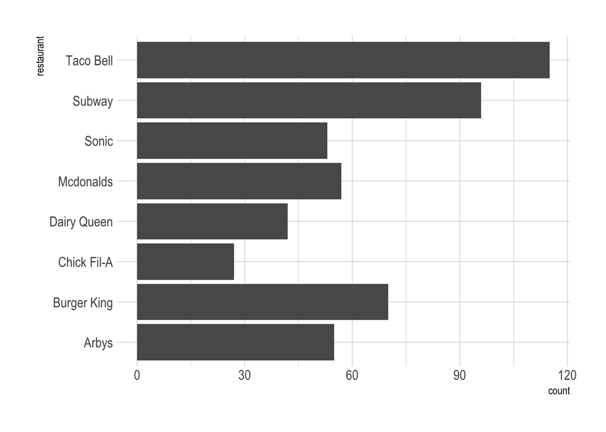

```r
FastFood %>%
  ggplot() +
  aes(x=restaurant) +
  geom_bar() +
  coord_flip()
```

## A Reordered Axis Plot

The required intermediate step is to count the labels. To accomplish this, group the data by restaurants and count the number of observations, then ungroup the data, and we can use the same technique as above.

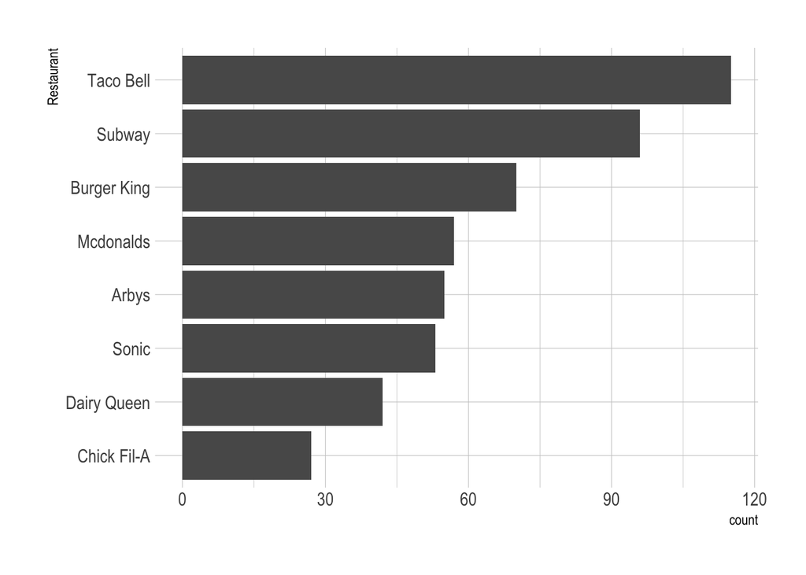

```r
FastFood %>%
  group_by(restaurant) %>%
  mutate(Count = n()) %>%
  ungroup() %>%
  ggplot() +
  aes(x=fct_reorder(restaurant, Count))  +
  geom_bar() +
  coord_flip() +
  labs(x="Restaurant")
```

# References

```r
knitr::write_bib(names(sessionInfo()$otherPkgs), file="bibliography.bib")
```

## References

Müller, Kirill, and Hadley Wickham. 2022. *Tibble: Simple Data Frames*. https://CRAN.R-project.org/package=tibble.

Rudis, Bob. 2020. *Hrbrthemes: Additional Themes, Theme Components and Utilities for Ggplot2*. http://github.com/hrbrmstr/hrbrthemes.

Wickham, Hadley. 2016. *Ggplot2: Elegant Graphics for Data Analysis*. Springer-Verlag New York. https://ggplot2.tidyverse.org.

———. 2022a. *Forcats: Tools for Working with Categorical Variables (Factors)*. https://CRAN.R-project.org/package=forcats.

———. 2022b. *Stringr: Simple, Consistent Wrappers for Common String Operations*. https://CRAN.R-project.org/package=stringr.

———. 2022c. *Tidyverse: Easily Install and Load the Tidyverse*. https://CRAN.R-project.org/package=tidyverse.

Wickham, Hadley, Mara Averick, Jennifer Bryan, Winston Chang, Lucy D’Agostino McGowan, Romain François, Garrett Grolemund, et al. 2019. “Welcome to the tidyverse.” *Journal of Open Source Software* 4 (43): 1686. https://doi.org/10.21105/joss.01686.

Wickham, Hadley, Winston Chang, Lionel Henry, Thomas Lin Pedersen, Kohske Takahashi, Claus Wilke, Kara Woo, Hiroaki Yutani, and Dewey Dunnington. 2022. *Ggplot2: Create Elegant Data Visualisations Using the Grammar of Graphics*. https://CRAN.R-project.org/package=ggplot2.

Wickham, Hadley, Romain François, Lionel Henry, and Kirill Müller. 2022. *Dplyr: A Grammar of Data Manipulation*. https://CRAN.R-project.org/package=dplyr.

Wickham, Hadley, and Maximilian Girlich. 2022. *Tidyr: Tidy Messy Data*. https://CRAN.R-project.org/package=tidyr.

Wickham, Hadley, and Lionel Henry. 2023. *Purrr: Functional Programming Tools*. https://CRAN.R-project.org/package=purrr.

Wickham, Hadley, Jim Hester, and Jennifer Bryan. 2022. *Readr: Read Rectangular Text Data*. https://CRAN.R-project.org/package=readr.

Xie, Yihui, Joe Cheng, and Xianying Tan. 2022. *DT: A Wrapper of the JavaScript Library DataTables*. https://github.com/rstudio/DT.

## Footnotes

[^1]: Thomas Mock (2022). Tidy Tuesday: A weekly data project aimed at the R ecosystem. https://github.com/rfordatascience/tidytuesday.
[^2]: Thomas Mock (2022). Tidy Tuesday: A weekly data project aimed at the R ecosystem. https://github.com/rfordatascience/tidytuesday.